# Reproducible research course study assignment week 2

Sebastian Schmeck

18 September 2017

## Introduction

It is now possible to collect a large amount of data about personal movement using activity monitoring devices such as a Fitbit, Nike Fuelband, or Jawbone Up. These type of devices are part of the “quantified self” movement - a group of enthusiasts who take measurements about themselves regularly to improve their health, to find patterns in their behavior, or because they are tech geeks. But these data remain under-utilized both because the raw data are hard to obtain and there is a lack of statistical methods and software for processing and interpreting the data.

This assignment makes use of data from a personal activity monitoring device. This device collects data at 5 minute intervals through out the day. The data consists of two months of data from an anonymous individual collected during the months of October and November, 2012 and include the number of steps taken in 5 minute intervals each day.

The data for this assignment can be downloaded from the course web site:

- Dataset: Activity monitoring data [52K]

The dataset is stored in a comma-separated-value (CSV) file and there are a total of 17,568 observations in this dataset.

## Loading the data

```r
library(readr)
activity <- read_csv("~/3. Training/2017-04 Data Science/5_reproducible research/week 2 assign/activity.csv",
                     col_types = cols(date = col_date(format = "%Y-%M-%d"),
                                      steps = col_double()))
```

## Histogram of number of steps per day

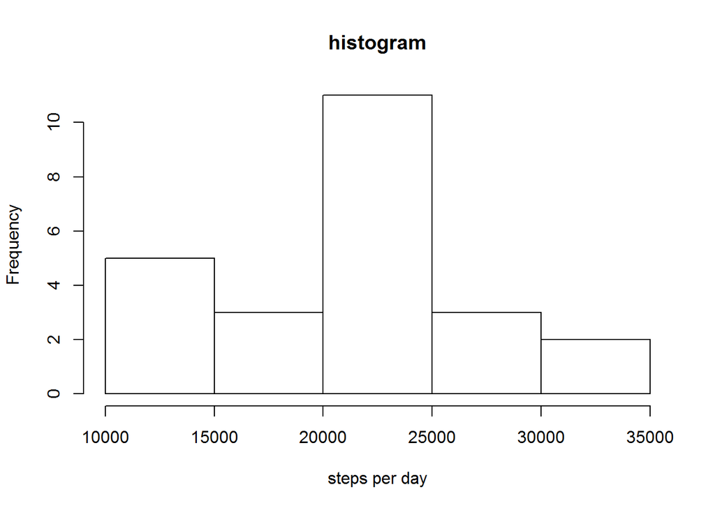

```r
stepsperday <- aggregate(activity$steps, list(Day=activity$date), FUN=sum)
hist(stepsperday$x, xlab = "steps per day", main = "histogram")
```

## Calculate the mean and median of steps per day

```r
mean(stepsperday$x, na.rm = TRUE)
```

```
## [1] 21151.88
```

```r
median(stepsperday$x, na.rm = TRUE)
```

```
## [1] 21782
```

## Time series plot for 5 minutes interval and average number across all days

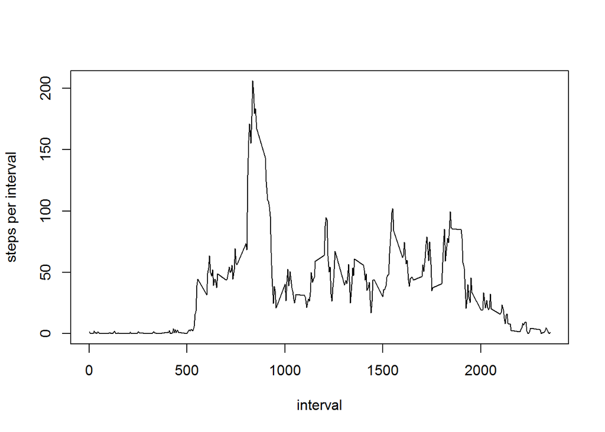

```r
stepsperinterval <- aggregate(activity$steps, list(Interval=activity$interval), mean, na.rm=TRUE)
plot(stepsperinterval$Interval, stepsperinterval$x, type = "l", xlab = "interval", ylab = "steps per interval")
```

## Maximum of average steps in which interval

```r
stepsperinterval[which(stepsperinterval$x == max(stepsperinterval$x)),]
```

```
##     Interval        x
## 104      835 206.1698
```

## Calculate the total number of missing values in the dataset

```r
sum(is.na(activity$steps))
```

```
## [1] 2304
```

## Create a new dataset, filling in the missing data by the mean of that interval

```r
library(plyr)
impute.mean <- function(x) replace(x, is.na(x), mean(x, na.rm = TRUE))
activity_new <- ddply(activity, ~ interval, transform, steps = impute.mean(steps))
```

## Histogram of the total number of steps taken each day

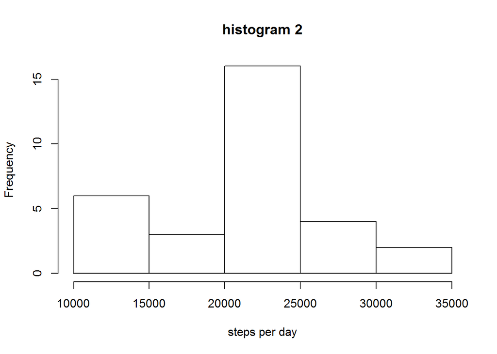

```r
stepsperday_new <- aggregate(activity_new$steps, list(Day=activity_new$date), FUN=sum)
hist(stepsperday_new$x, xlab = "steps per day", main = "histogram 2")
```